# Analysis of Limb Volume

Caleb Pollock

2023-01-11

The data and code can be found at https://github.com/caleb-pollock/BIOL432_Assignment1

# Introduction

```r
#here we set all of our libraries and also set the theme to the coulatti theme
library(dplyr)
```

```r
library(tidyr)
library(ggplot2)
source("http://bit.ly/theme_pub")
theme_set(theme_pub())
```

# Import dataGenerato.R

To begin, we will import our data generator script which will create a data frame sampling 100 species names, limb widths, limb heights, and observers. This will then be output into a csv file known as measurements.csv

```r
source('dataGenerato.R')
```

# Import volumeEstimato.R

Next, we use the csv file generated in the original script to add a new column which calculates the volume from the width and height values generated in the previous script. This includes using dplyrs pipe and mutate functions to add a new column, and we use the volume of a cylinder to calculate the volume of an organisms leg. This will then replace the measurements.csv file to include the new column.

```r
source('volumeEstimato.R')
```

# Import measurements.csv

After executing both of the R scripts, we move onto loading the revised measurements.csv file.

```r
#creating a new dataframe containing the measurements.csv data and loading the revised measurements.csv
measurementDat <- read.csv("measurements.csv")
head(measurementDat)
```

```
##            Organism Limb_Width Limb_Height  Observer   Volume
## 1      Homo erectus  11.123606    65.91627 Kennedy R 6405.805
## 2   Homo luzonensis   8.896594    95.53533   Caleb P 5938.838
## 3      Homo erectus   6.947745    69.35719 Kennedy R 2629.475
## 4 Denisova hominins  11.224396    76.59586 Kennedy R 7579.162
## 5      Homo sapiens   9.181434    58.63822 Kennedy R 3882.324
## 6 Denisova hominins  10.549888    72.43874   Louie Y 6332.227
```

# Sort by Organism, Observer, Volume

We will now use dplyr to sort the data by species, than by observer, than by limb volume

```r
#apply the arrange function using the measurementDat dataframe and pipe to create a new dataframe which is arranged properly with Organism > Species > Volume
measurementDat <- measurementDat %>%
  arrange(Organism, Observer, Volume)
#you will now be able to see the data grouped by species, then by observer, and finally lowest to highest volume
head(measurementDat)
```

```
##            Organism Limb_Width Limb_Height  Observer   Volume
## 1 Denisova hominins  10.615085    75.18631   Caleb P 6653.890
## 2 Denisova hominins   9.680634    94.38640   Caleb P 6947.153
## 3 Denisova hominins  11.754327    82.74658   Caleb P 8979.155
## 4 Denisova hominins   7.977675    89.51393 Kennedy R 4474.383
## 5 Denisova hominins   9.322120    79.98959 Kennedy R 5459.499
## 6 Denisova hominins   7.968400   109.88358 Kennedy R 5479.803
```

# Average Volume

Following sorting the dataframe, we will now create a table showing the average volume for each species

```r
#using dplyr pipes, group_by() and sumarise() will allow use to create a table with average volume for each species. This will create a new dataframe called measurementTab that will be a table of the average volume for each species
measurementTab <- measurementDat %>%
  group_by(Organism) %>%
  summarize(AverageVol = mean(Volume))
head(measurementTab)
```

```
## # A tibble: 5 x 2
##   Organism              AverageVol
##   <chr>                      <dbl>
## 1 Denisova hominins          7154.
## 2 Homo erectus               7314.
## 3 Homo luzonensis            6437.
## 4 Homo neanderthalensis      5303.
## 5 Homo sapiens               5452.
```

# Number of Observations

Following the average volume per species table, we will create a new table which sorts how many times an observer made observations on a particular organism.

```r
#using similar methods to the table above, we apply measurementDat to a new dataframe called speciesObsTab, which will be a table containing Organism, observer, and observations. group_by() will select the organism and observer to be included in the new table, and summarize() will return the current group size (n()) under a new column called Observations.
speciesObsTab <- measurementDat %>%
  group_by(Organism, Observer) %>%
  summarize(Observations = n())
head(speciesObsTab)
```

```
## # A tibble: 6 x 3
## # Groups:   Organism [2]
##   Organism          Observer  Observations
##   <chr>             <chr>            <int>
## 1 Denisova hominins Caleb P              3
## 2 Denisova hominins Kennedy R            7
## 3 Denisova hominins Louie Y              8
## 4 Homo erectus      Caleb P              4
## 5 Homo erectus      Kennedy R           11
## 6 Homo erectus      Louie Y              5
```

# Single Box Plot

Next we want to create a single box plot showing showing the distribution of limb volume for each species. This is done through ggplot2, by selecting our data and x and y variables and adding geom_boxplot.

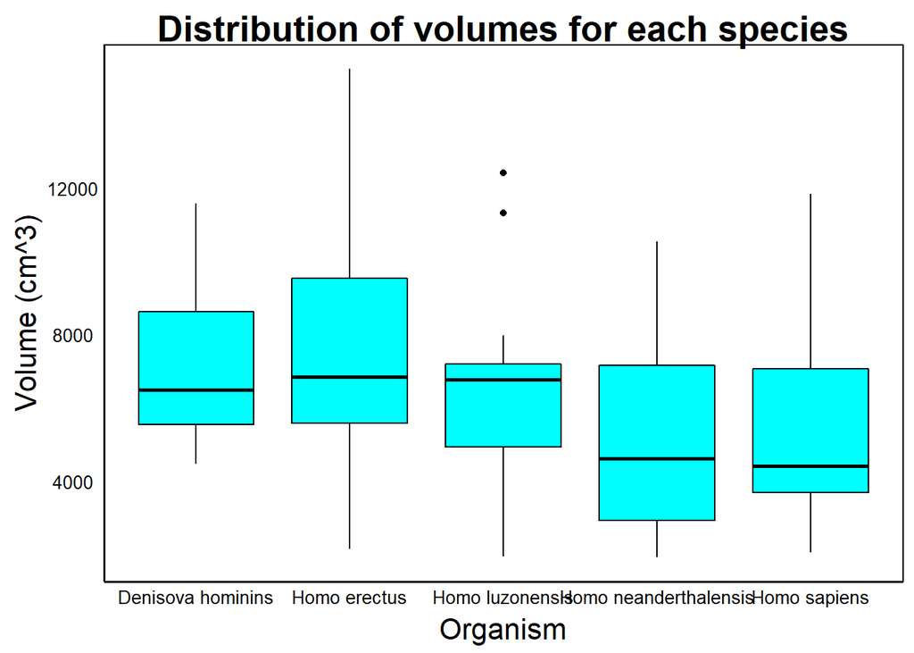

```r
#To create a boxplot to compare the distributions of volumes for each species, we use ggplot2 to first select our data, and x and y variables fit inside of the aes function. We then add the geom_boxplot() to get our results
#The labs function allows us to edit the x, y and title of the graph
ggplot(measurementDat, aes(x=Organism, y= Volume)) +
  geom_boxplot(fill = "cyan", colour = 'black') +
  labs(title = "Distribution of volumes for each species",
       y = "Volume (cm^3)")
```

# Multi-panel Plot

Finally, to finish the report, we need to generate a multi-panel plot which shows the frequency histograms showing the distribution of limb volume per species. This is preformed by using geom_histogram.

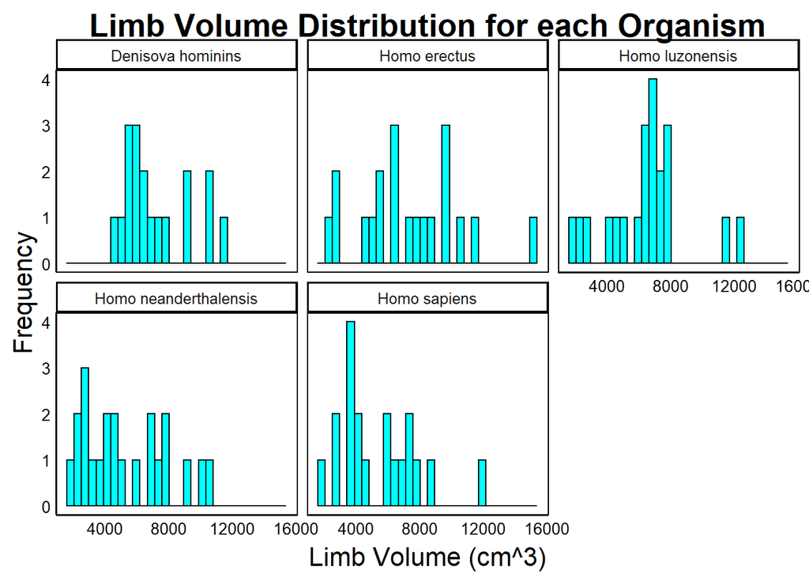

```r
#using ggplot, we select our data to be the measurement data, and our x axis value is volume. The y axis is a frequency calculation, or number of volumes that fall under a certain range
#geom histogram is used to add colour to the graph, cyan is selected because it looks nice in my opinion
#facet_wrap allows us to add multiple graphs to the same panel, and by selecting ~Organism, each graph is sorted by the respective species
#The labs function allows us to add titles/axis labels similar to above
ggplot(data = measurementDat, aes(x = Volume)) +
  geom_histogram(fill = 'cyan', color = 'black') +
  facet_wrap(~Organism) + labs(title = "Limb Volume Distribution for each Organism",
       x = "Limb Volume (cm^3)",
       y = "Frequency")
```